# Practical Machine Learning Course Project

Adam Ficke

6/20/2020

## Problem Statement

This project aims to classify users’ exercise technique using data from a personal fitness device.

This paper will discuss the methods used for explotatory data analysis, feature selection, model selection, and performance evaluation, and will ultimately show modeled results on an independent test dataset.

All data in this project is sourced from http://groupware.les.inf.puc-rio.br/har

*Velloso, E.; Bulling, A.; Gellersen, H.; Ugulino, W.; Fuks, H. Qualitative Activity Recognition of Weight Lifting Exercises. Proceedings of 4th International Conference in Cooperation with SIGCHI (Augmented Human ’13) . Stuttgart, Germany: ACM SIGCHI, 2013.*

*Creative Commons license (CC BY-SA)*

## EDA

First we’ll examine the data for zero or near zero variance so that we can remove them from our predictors.

|  | freqRatio | percentUnique | zeroVar | nzv |
| --- | --- | --- | --- | --- |
| X | 1.000000 | 100.0000000 | FALSE | FALSE |
| user_name | 1.100679 | 0.0305779 | FALSE | FALSE |
| raw_timestamp_part_1 | 1.000000 | 4.2656202 | FALSE | FALSE |
| raw_timestamp_part_2 | 1.000000 | 85.5315462 | FALSE | FALSE |
| cvtd_timestamp | 1.000668 | 0.1019264 | FALSE | FALSE |
| new_window | 47.330049 | 0.0101926 | FALSE | TRUE |
| num_window | 1.000000 | 4.3726430 | FALSE | FALSE |
| roll_belt | 1.101904 | 6.7781062 | FALSE | FALSE |
| pitch_belt | 1.036083 | 9.3772296 | FALSE | FALSE |
| yaw_belt | 1.058480 | 9.9734991 | FALSE | FALSE |

We’ll also search for features that have mostly invalid data, and filter those out.

```r
zeros <- colMeans(!is.na(FilteredData)) > .97
FilteredData <- FilteredData[zeros]
FilteredTest <- FilteredTest[zeros]
zs<-as.matrix(summary(zeros))
knitr::kable(zs, align = "c")%>%
  kable_styling(full_width = F)
```

| Mode | logical |
| --- | --- |
| FALSE | 41 |
| TRUE | 59 |

Now we need to standardize the variables types. First we’ll review what the types currently are for the training and test sets, then change them all to correspond with an appropriate type.

| variable | classe | first_values |
| --- | --- | --- |
| user_name | character | carlitos, carlitos, carlitos, carlitos, carlitos, carlitos |
| roll_belt | double | 1.41, 1.41, 1.42, 1.48, 1.48, 1.45 |
| pitch_belt | double | 8.07, 8.07, 8.07, 8.05, 8.07, 8.06 |
| yaw_belt | double | -94.4, -94.4, -94.4, -94.4, -94.4, -94.4 |
| total_accel_belt | integer | 3, 3, 3, 3, 3, 3 |
| gyros_belt_x | double | 0, 0.02, 0, 0.02, 0.02, 0.02 |
| gyros_belt_y | double | 0, 0, 0, 0, 0.02, 0 |
| gyros_belt_z | double | -0.02, -0.02, -0.02, -0.03, -0.02, -0.02 |
| accel_belt_x | integer | -21, -22, -20, -22, -21, -21 |
| accel_belt_y | integer | 4, 4, 5, 3, 2, 4 |
| accel_belt_z | integer | 22, 22, 23, 21, 24, 21 |
| magnet_belt_x | integer | -3, -7, -2, -6, -6, 0 |
| magnet_belt_y | integer | 599, 608, 600, 604, 600, 603 |
| magnet_belt_z | integer | -313, -311, -305, -310, -302, -312 |
| roll_arm | double | -128, -128, -128, -128, -128, -128 |
| pitch_arm | double | 22.5, 22.5, 22.5, 22.1, 22.1, 22 |
| yaw_arm | double | -161, -161, -161, -161, -161, -161 |
| total_accel_arm | integer | 34, 34, 34, 34, 34, 34 |
| gyros_arm_x | double | 0, 0.02, 0.02, 0.02, 0, 0.02 |
| gyros_arm_y | double | 0, -0.02, -0.02, -0.03, -0.03, -0.03 |
| gyros_arm_z | double | -0.02, -0.02, -0.02, 0.02, 0, 0 |
| accel_arm_x | integer | -288, -290, -289, -289, -289, -289 |
| accel_arm_y | integer | 109, 110, 110, 111, 111, 111 |
| accel_arm_z | integer | -123, -125, -126, -123, -123, -122 |
| magnet_arm_x | integer | -368, -369, -368, -372, -374, -369 |
| magnet_arm_y | integer | 337, 337, 344, 344, 337, 342 |
| magnet_arm_z | integer | 516, 513, 513, 512, 506, 513 |
| roll_dumbbell | double | 13.05217456, 13.13073959, 12.85074981, 13.43119971, 13.37871611, 13.38245941 |
| pitch_dumbbell | double | -70.49400371, -70.63750507, -70.27811982, -70.39379464, -70.42855971, -70.81758832 |
| yaw_dumbbell | double | -84.87393888, -84.71064711, -85.14078134, -84.87362553, -84.85305745, -84.46500278 |
| total_accel_dumbbell | integer | 37, 37, 37, 37, 37, 37 |
| gyros_dumbbell_x | double | 0, 0, 0, 0, 0, 0 |
| gyros_dumbbell_y | double | -0.02, -0.02, -0.02, -0.02, -0.02, -0.02 |
| gyros_dumbbell_z | double | 0, 0, 0, -0.02, 0, 0 |
| accel_dumbbell_x | integer | -234, -233, -232, -232, -233, -234 |
| accel_dumbbell_y | integer | 47, 47, 46, 48, 48, 48 |
| accel_dumbbell_z | integer | -271, -269, -270, -269, -270, -269 |
| magnet_dumbbell_x | integer | -559, -555, -561, -552, -554, -558 |
| magnet_dumbbell_y | integer | 293, 296, 298, 303, 292, 294 |
| magnet_dumbbell_z | double | -65, -64, -63, -60, -68, -66 |
| roll_forearm | double | 28.4, 28.3, 28.3, 28.1, 28, 27.9 |
| pitch_forearm | double | -63.9, -63.9, -63.9, -63.9, -63.9, -63.9 |
| yaw_forearm | double | -153, -153, -152, -152, -152, -152 |
| total_accel_forearm | integer | 36, 36, 36, 36, 36, 36 |
| gyros_forearm_x | double | 0.03, 0.02, 0.03, 0.02, 0.02, 0.02 |
| gyros_forearm_y | double | 0, 0, -0.02, -0.02, 0, -0.02 |
| gyros_forearm_z | double | -0.02, -0.02, 0, 0, -0.02, -0.03 |
| accel_forearm_x | integer | 192, 192, 196, 189, 189, 193 |
| accel_forearm_y | integer | 203, 203, 204, 206, 206, 203 |
| accel_forearm_z | integer | -215, -216, -213, -214, -214, -215 |
| magnet_forearm_x | integer | -17, -18, -18, -16, -17, -9 |
| magnet_forearm_y | double | 654, 661, 658, 658, 655, 660 |
| magnet_forearm_z | double | 476, 473, 469, 469, 473, 478 |
| classe | character | A, A, A, A, A, A |

Now that the data is clean, we’ll split out our training set into a 70/30 train/test split.

```r
set.seed(250)
trainIndex <- createDataPartition(FilteredData$classe, p = .7,
                                  list = FALSE,
                                  times = 1)

train <- FilteredData[trainIndex, ]
valid <- FilteredData[-trainIndex, ]
```

## Model Selection

Since these are classification problems where the interpretability of the model is less important than the accuracy, we’ll try a couple of machine learning models: GBM and Random Forest.

These models have a tendancy to overfit, so we’ll make sure to use cross-validation. We’re using the default values of 10 k-folds, and 10 repeats.

### GBM

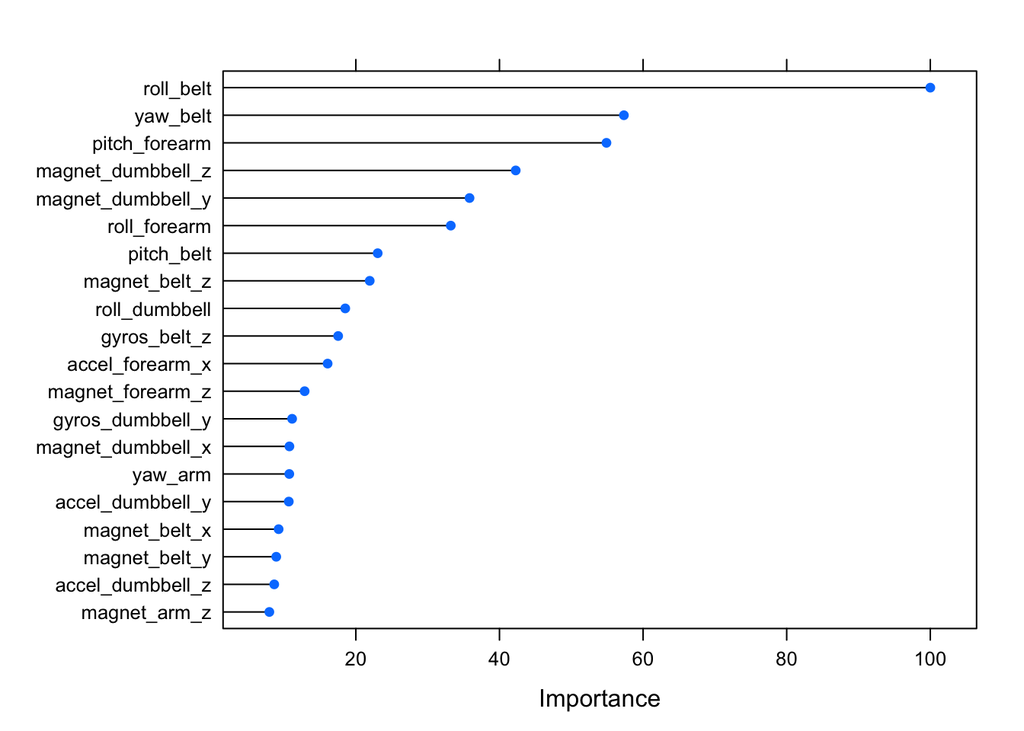

```r
cl <- makePSOCKcluster(8)
registerDoParallel(cl)

fitControl <- trainControl(
  method = "repeatedcv",
  number = 10,
  repeats = 10)


set.seed(250)
gbmFit1 <- train(
  classe ~ .,
  data = train,
  method = "gbm",
  trControl = fitControl,
  verbose = FALSE,
  na.action = na.pass
)
stopCluster(cl)
```

### Random Forest

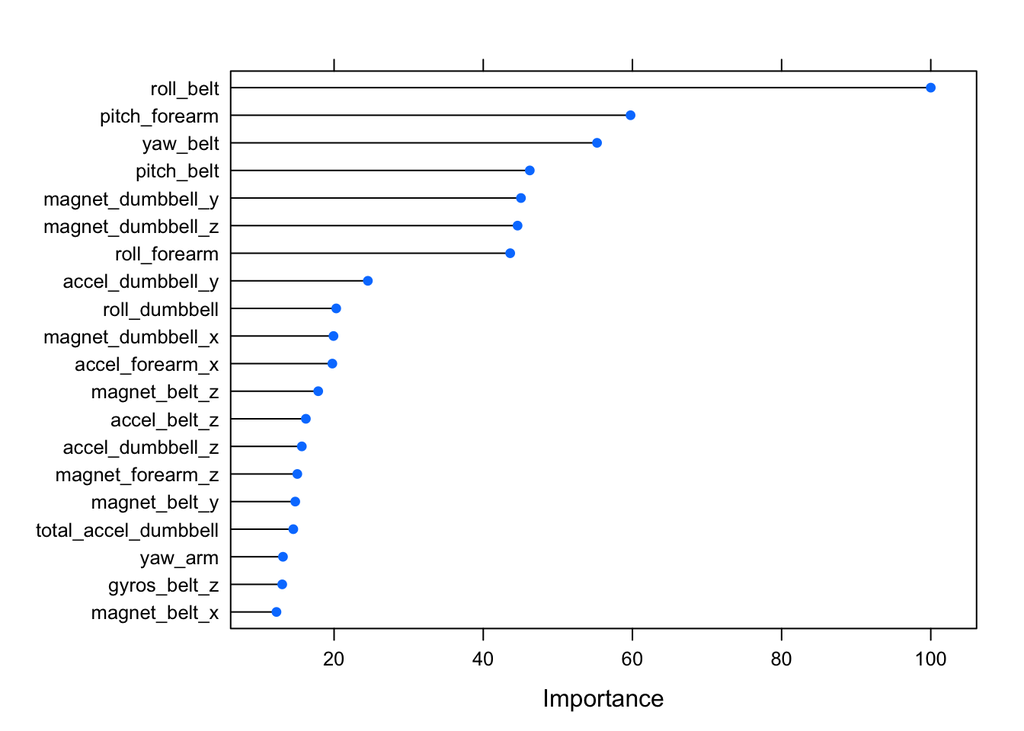

```r
cl <- makePSOCKcluster(8)
registerDoParallel(cl)

set.seed(250)
rfFit1 <- train(
  classe ~ .,
  data = train,
  method = "rf",
  trControl = fitControl,
  na.action = na.pass
)

stopCluster(cl)
registerDoSEQ()
```

## Performance

Now we’ll look at the confusion matrix to assess the accuracy of each model.

### GBM Performance

```
## Confusion Matrix and Statistics
##
##           Reference
## Prediction    A    B    C    D    E
##          A 1645   42    0    0    0
##          B   14 1055   36    4    4
##          C   11   41  976   25    7
##          D    3    1   13  927   13
##          E    1    0    1    8 1058
##
## Overall Statistics
##
##                Accuracy : 0.9619
##                  95% CI : (0.9567, 0.9667)
##     No Information Rate : 0.2845
##     P-Value [Acc > NIR] : < 2.2e-16
##
##                   Kappa : 0.9518
##
##  Mcnemar's Test P-Value : 2.563e-06
##
## Statistics by Class:
##
##                      Class: A Class: B Class: C Class: D Class: E
## Sensitivity            0.9827   0.9263   0.9513   0.9616   0.9778
## Specificity            0.9900   0.9878   0.9827   0.9939   0.9979
## Pos Pred Value         0.9751   0.9479   0.9208   0.9687   0.9906
## Neg Pred Value         0.9931   0.9824   0.9896   0.9925   0.9950
## Prevalence             0.2845   0.1935   0.1743   0.1638   0.1839
## Detection Rate         0.2795   0.1793   0.1658   0.1575   0.1798
## Detection Prevalence   0.2867   0.1891   0.1801   0.1626   0.1815
## Balanced Accuracy      0.9864   0.9570   0.9670   0.9778   0.9879
```

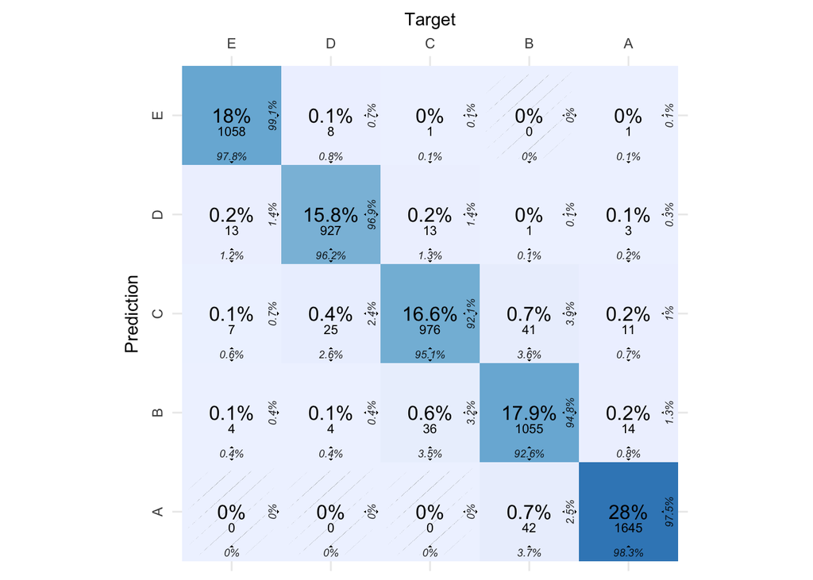

### Random Forest Performance

```
## Confusion Matrix and Statistics
##
##           Reference
## Prediction    A    B    C    D    E
##          A 1671    7    0    0    0
##          B    1 1130    4    0    2
##          C    2    2 1014    7    0
##          D    0    0    8  956    4
##          E    0    0    0    1 1076
##
## Overall Statistics
##
##                Accuracy : 0.9935
##                  95% CI : (0.9911, 0.9954)
##     No Information Rate : 0.2845
##     P-Value [Acc > NIR] : < 2.2e-16
##
##                   Kappa : 0.9918
##
##  Mcnemar's Test P-Value : NA
##
## Statistics by Class:
##
##                      Class: A Class: B Class: C Class: D Class: E
## Sensitivity            0.9982   0.9921   0.9883   0.9917   0.9945
## Specificity            0.9983   0.9985   0.9977   0.9976   0.9998
## Pos Pred Value         0.9958   0.9938   0.9893   0.9876   0.9991
## Neg Pred Value         0.9993   0.9981   0.9975   0.9984   0.9988
## Prevalence             0.2845   0.1935   0.1743   0.1638   0.1839
## Detection Rate         0.2839   0.1920   0.1723   0.1624   0.1828
## Detection Prevalence   0.2851   0.1932   0.1742   0.1645   0.1830
## Balanced Accuracy      0.9983   0.9953   0.9930   0.9946   0.9971
```

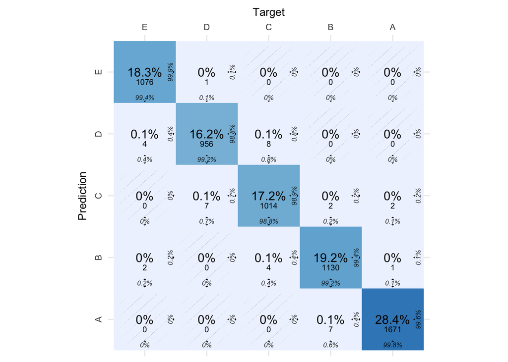

## Predictions

The last step is to use our models to predict on unknown quantities. Since both models seem to perform well, we’ll run predictions using each and compare the results. In this case All of the predictions agree, which gives more confidence in the results.

| ProblemID | GBM_Predictions | Random_Forest_Predictions |
| --- | --- | --- |
| 1 | B | B |
| 2 | A | A |
| 3 | B | B |
| 4 | A | A |
| 5 | A | A |
| 6 | E | E |
| 7 | D | D |
| 8 | B | B |
| 9 | A | A |
| 10 | A | A |
| 11 | B | B |
| 12 | C | C |
| 13 | B | B |
| 14 | A | A |
| 15 | E | E |
| 16 | E | E |
| 17 | A | A |
| 18 | B | B |
| 19 | B | B |
| 20 | B | B |